# Disturbance type model_3/15/2021

Kai Kopecky

3/15/2021

### The model

#### State Variables for proportional cover of benthic space holders

$$\begin{align}
&C_L\ =\ Live\ coral\ cover\\
\newline
&C_D\ =\ Dead\ coral\ cover\\
\newline
&M_S\ =\ Macroalgae\ cover\ on\ open\ substrate\\
\newline
&M_C\ =\ Macroalgae\ cover\ on\ dead\ coral\\
\newline
&S\ =\ Open\ Substrate\\
\end{align}$$

#### Ordinary differential equations

Rates of change for proportional spatial cover of live coral, dead coral, and macroalgae on either open substrate or dead coral
$$\begin{align}
&\frac{d C_L}{dt} = g_c C_L S + \gamma_cS - g_{mC_L} C_L(M_S + M_C) - d_c C_L \\
\newline
&\frac{d C_D}{dt} = d_c C_L + M_C(h_{mc} + d_m) - g_m C_D (M_S + M_C) - e C_D \\
\newline
&\frac{d M_S}{dt} = g_m M_S S + g_m M_C S + \gamma_mS - M_S(h_{ms} + d_m)\\
\newline
&\frac{d M_C}{dt} = g_m M_C C_D + g_m M_S C_D + g_{mC_L} C_L(M_S + M_C) + \gamma_mC_D - M_C(h_{mc} + d_m + e)\\
\newline
&\ S = 1 - C_L - C_D - M_S - M_C \\
\newline
\end{align}$$

#### Parameters for ODE’s

$$\begin{align}
&g_c\ =\ Growth\ rate\ of\ live\ coral\\
&g_m\ =\ Growth\ rate\ of\ macroalgae\\
&g_{mC_L}\ =\ Growth\ rate\ of\ macroalgae\ onto\ live\ coral\\
&d_c\ =\ Ambient\ mortality\ of\ coral\\
&d_m\ =\ Ambient\ mortality\ of\ macroalgae\\
&e\ =\ Erosion\ of\ dead\ coral\\
&\gamma_c\ =\ Settlement\ rate\ of\ coral\\
&\gamma_m\ =\ Settlement\ rate\ of\ macroalgae\\
&h_{ms}\ =\ herbivory\ rate\ of\ macroalgae\ on\ open\ substrate\\
&h_{mc}\ =\ herbivory\ rate\ of\ macroalgae\ on\ dead\ coral\\
&\end{align}$$

### Time series

#### Ten year frequency

50% structure-removing disturbances every ten years

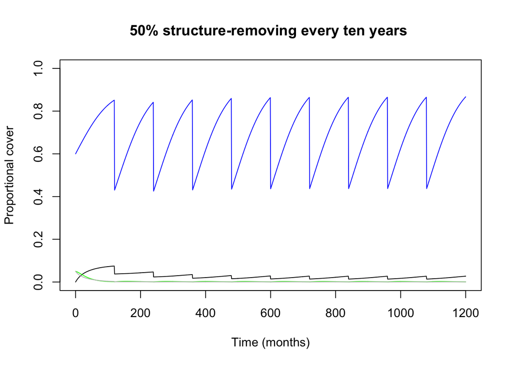

50% structure-retaining disturbances every ten years

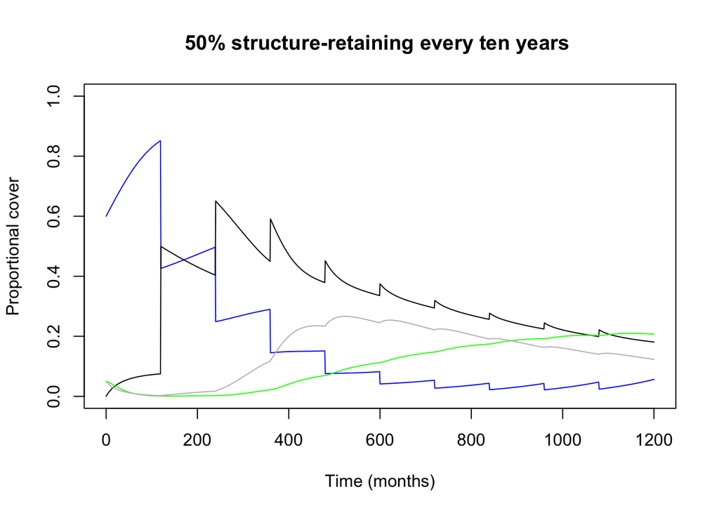

#### Five year frequency

50% structure-removing disturbances every five years

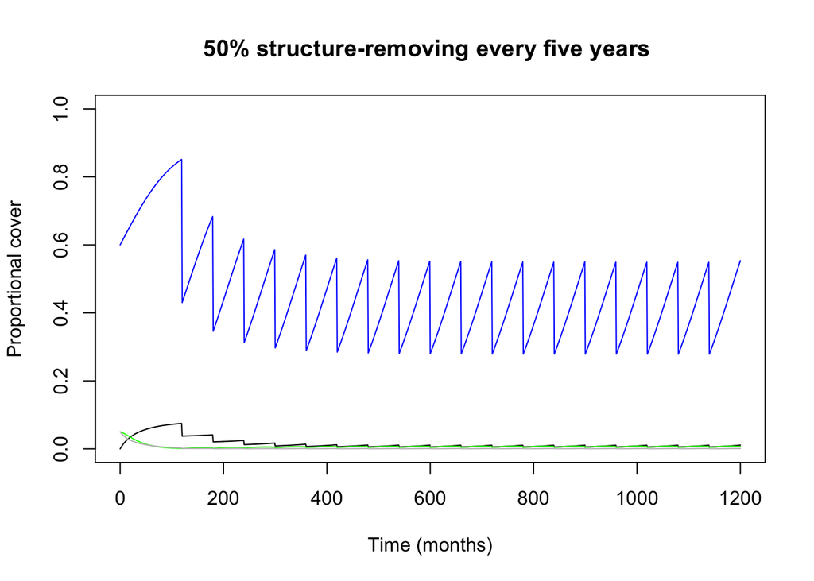

50% structure-retaining disturbances every five years

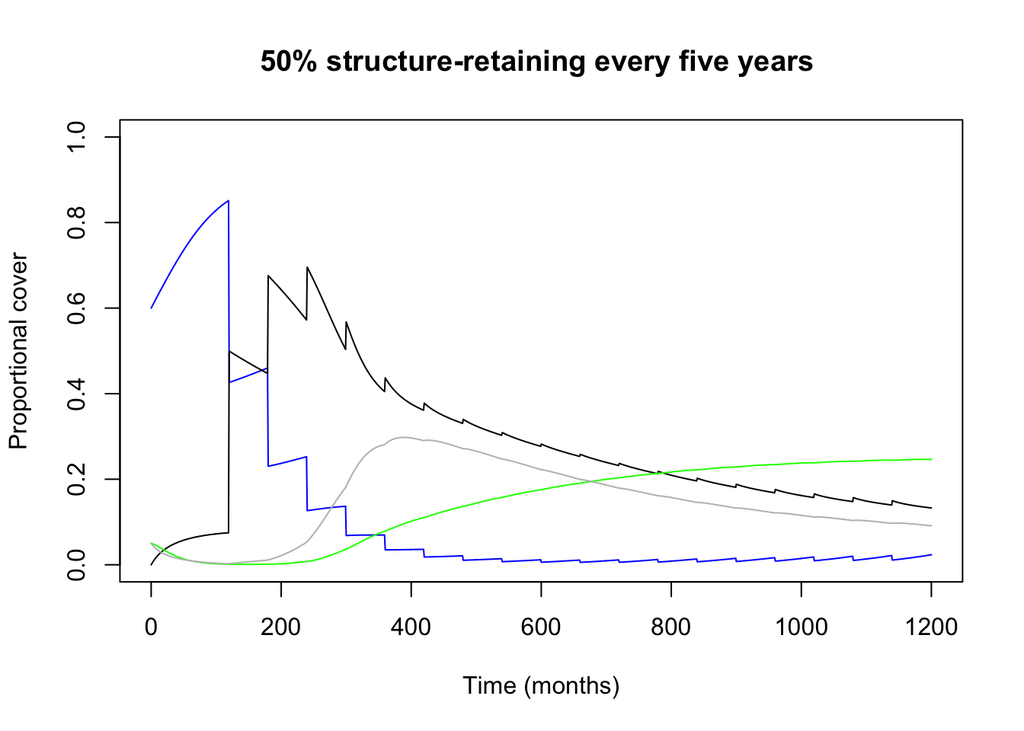

### Equilibrium cover for different frequencies

#### Equilibrium cover for ten year frequency

Structure-removing disturbances

Structure-retaining disturbances

#### Equilibrium cover for five year frequency

Structure-removing disturbances

Structure-retaining disturbances

Equilibrium cover plots for five and ten year frequencies

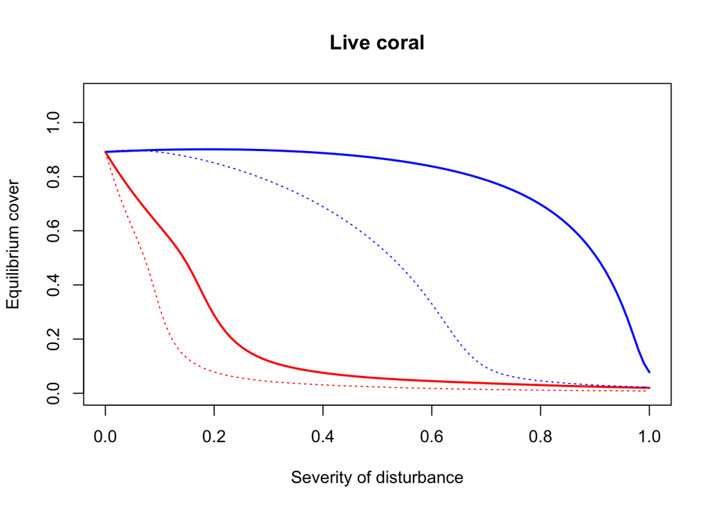

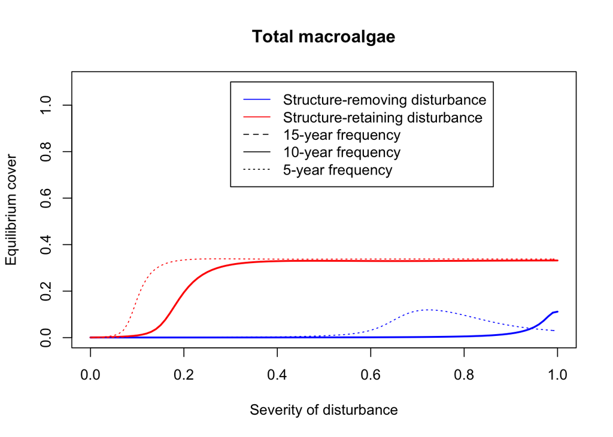

### Disturbance sequences

#### Time series for different sequences ten years apart

Structure removing first, ten years apart (The Oli-bleaching scenario)

Structure-retaining ten years after structure removing

Plot of time series for structure removing followed by structure retaining disturbance, ten years apart

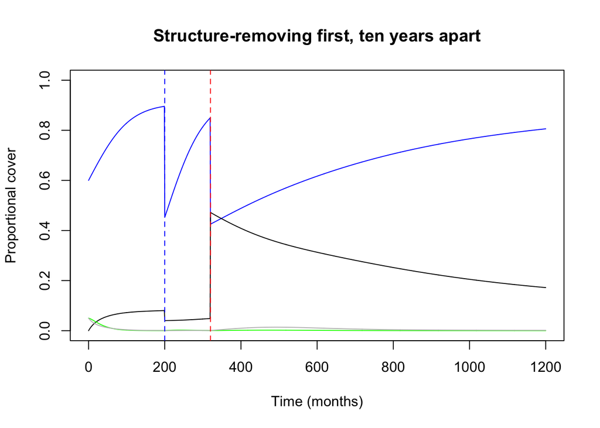

Structure-retaining first 10 years before structure-removing

Structure-removing 10 years after structure-retaining

Plot of time series for structure retaining followed by structure removing disturbance 10 years later

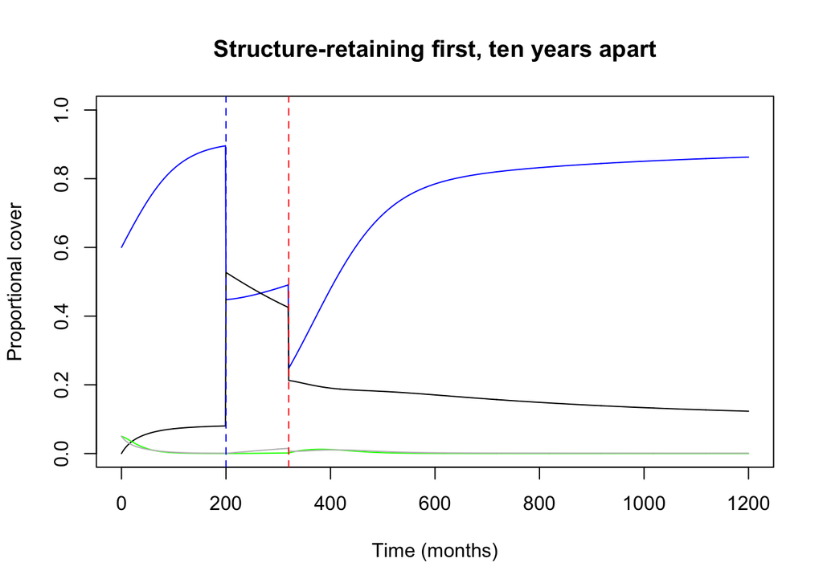

#### Time series for different sequences 5 years apart

Structure-retaining disturbance 5 years before structure-removing

Structure-removing 5 years after structure-retaining

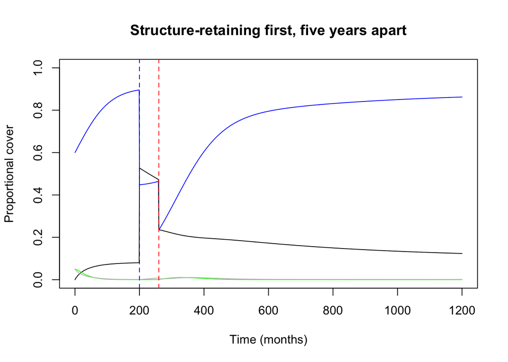

Structure removing first, five years before structure-retaining

Structure-retaining disturbance five years after structure removing

Plot of time series for structure removing followed by structure retaining disturbance, 5 years apart

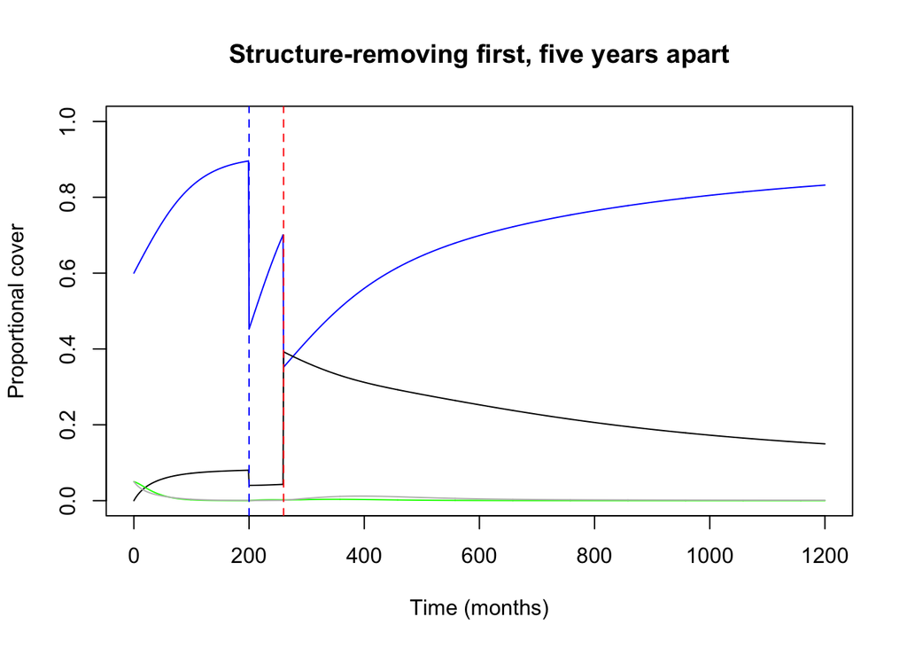